# Decision Tree Classification and Evaluation

Ahsan Ahmad

March 10, 2024

# 1 Libraries

```r
library(tidyverse)
library(psych)
```

```r
library(RWeka)
library(rmarkdown)
library(scatterplot3d)
library(caret)
library(C50)
library(rminer)
```

# 2 Import a csv file and changing categorical data to factors

Before proceeding with the analysis, it’s essential to set up the working directory and import the data from a CSV file named ‘CD_additional_balanced-1.csv’. This code chunk also inspects the structure of the dataset and converts categorical variables into factors for further analysis.

```r
# Setting up working directory and importing data from a csv file

cloud_wd <- getwd()
setwd(cloud_wd)

CD_balance <- read.csv(file = "CD_additional_balanced-1.csv", stringsAsFactors = FALSE)
str(CD_balance)
```

```
## 'data.frame':    9280 obs. of  21 variables:
##  $ age           : int  41 49 49 41 45 42 39 28 44 42 ...
##  $ job           : chr  "blue-collar" "entrepreneur" "technician" "technician" ...
##  $ marital       : chr  "divorced" "married" "married" "married" ...
##  $ education     : chr  "basic.4y" "university.degree" "basic.9y" "professional.course" ...
##  $ default       : chr  "unknown" "unknown" "no" "unknown" ...
##  $ housing       : chr  "yes" "yes" "no" "yes" ...
##  $ loan          : chr  "no" "no" "no" "no" ...
##  $ contact       : chr  "telephone" "telephone" "telephone" "telephone" ...
##  $ month         : chr  "may" "may" "may" "may" ...
##  $ day_of_week   : chr  "mon" "mon" "mon" "mon" ...
##  $ duration      : int  1575 1042 1467 579 461 673 935 1201 1030 1623 ...
##  $ campaign      : int  1 1 1 1 1 2 3 1 1 1 ...
##  $ pdays         : int  999 999 999 999 999 999 999 999 999 999 ...
##  $ previous      : int  0 0 0 0 0 0 0 0 0 0 ...
##  $ poutcome      : chr  "nonexistent" "nonexistent" "nonexistent" "nonexistent" ...
##  $ emp.var.rate  : num  1.1 1.1 1.1 1.1 1.1 1.1 1.1 1.1 1.1 1.1 ...
##  $ cons.price.idx: num  94 94 94 94 94 ...
##  $ cons.conf.idx : num  -36.4 -36.4 -36.4 -36.4 -36.4 -36.4 -36.4 -36.4 -36.4 -36.4 ...
##  $ euribor3m     : num  4.86 4.86 4.86 4.86 4.86 ...
##  $ nr.employed   : num  5191 5191 5191 5191 5191 ...
##  $ y             : chr  "yes" "yes" "yes" "yes" ...
```

```r
# Changing Categorical data to factors

CD_balance$job <- factor(CD_balance$job)
CD_balance$marital <- factor(CD_balance$marital)
CD_balance$education <- factor(CD_balance$education)
CD_balance$default <- factor(CD_balance$default)
CD_balance$housing <- factor(CD_balance$housing)
CD_balance$loan <- factor(CD_balance$loan)
CD_balance$contact <- factor(CD_balance$contact)
CD_balance$month <- factor(CD_balance$month)
CD_balance$day_of_week <- factor(CD_balance$day_of_week)
CD_balance$poutcome <- factor(CD_balance$poutcome)
CD_balance$y <- factor(CD_balance$y)

# Looking at the structure and summary of the data

str(CD_balance)
```

```
## 'data.frame':    9280 obs. of  21 variables:
##  $ age           : int  41 49 49 41 45 42 39 28 44 42 ...
##  $ job           : Factor w/ 12 levels "admin.","blue-collar",..: 2 3 10 10 2 2 4 12 8 10 ...
##  $ marital       : Factor w/ 4 levels "divorced","married",..: 1 2 2 2 2 2 2 3 2 2 ...
##  $ education     : Factor w/ 8 levels "basic.4y","basic.6y",..: 1 7 3 6 3 3 3 8 4 6 ...
##  $ default       : Factor w/ 2 levels "no","unknown": 2 2 1 2 2 1 1 2 1 1 ...
##  $ housing       : Factor w/ 3 levels "no","unknown",..: 3 3 1 3 3 3 3 3 3 1 ...
##  $ loan          : Factor w/ 3 levels "no","unknown",..: 1 1 1 1 1 3 1 3 1 1 ...
##  $ contact       : Factor w/ 2 levels "cellular","telephone": 2 2 2 2 2 2 2 2 2 2 ...
##  $ month         : Factor w/ 10 levels "apr","aug","dec",..: 7 7 7 7 7 7 7 7 7 7 ...
##  $ day_of_week   : Factor w/ 5 levels "fri","mon","thu",..: 2 2 2 2 2 2 2 4 4 4 ...
##  $ duration      : int  1575 1042 1467 579 461 673 935 1201 1030 1623 ...
##  $ campaign      : int  1 1 1 1 1 2 3 1 1 1 ...
##  $ pdays         : int  999 999 999 999 999 999 999 999 999 999 ...
##  $ previous      : int  0 0 0 0 0 0 0 0 0 0 ...
##  $ poutcome      : Factor w/ 3 levels "failure","nonexistent",..: 2 2 2 2 2 2 2 2 2 2 ...
##  $ emp.var.rate  : num  1.1 1.1 1.1 1.1 1.1 1.1 1.1 1.1 1.1 1.1 ...
##  $ cons.price.idx: num  94 94 94 94 94 ...
##  $ cons.conf.idx : num  -36.4 -36.4 -36.4 -36.4 -36.4 -36.4 -36.4 -36.4 -36.4 -36.4 ...
##  $ euribor3m     : num  4.86 4.86 4.86 4.86 4.86 ...
##  $ nr.employed   : num  5191 5191 5191 5191 5191 ...
##  $ y             : Factor w/ 2 levels "no","yes": 2 2 2 2 2 2 2 2 2 2 ...
```

```r
summary(CD_balance)
```

```
##       age                job           marital                   education
##  Min.   :17.0   admin.     :2517   divorced:1021   university.degree  :3007
##  1st Qu.:31.0   blue-collar:1769   married :5338   high.school        :2102
##  Median :38.0   technician :1459   single  :2900   professional.course:1190
##  Mean   :40.4   services   : 773   unknown :  21   basic.9y           :1177
##  3rd Qu.:48.0   management : 651                   basic.4y           : 895
##  Max.   :98.0   retired    : 595                   basic.6y           : 458
##                 (Other)    :1516                   (Other)            : 451
##     default        housing          loan           contact         month
##  no     :7824   no     :4104   no     :7688   cellular :6672   may    :2533
##  unknown:1456   unknown: 225   unknown: 225   telephone:2608   jul    :1477
##                 yes    :4951   yes    :1367                    aug    :1353
##                                                                jun    :1169
##                                                                nov    : 886
##                                                                apr    : 785
##                                                                (Other):1077
##  day_of_week    duration         campaign          pdays          previous
##  fri:1763    Min.   :   1.0   Min.   : 1.000   Min.   :  0.0   Min.   :0.0000
##  mon:1846    1st Qu.: 145.0   1st Qu.: 1.000   1st Qu.:999.0   1st Qu.:0.0000
##  thu:2000    Median : 265.0   Median : 2.000   Median :999.0   Median :0.0000
##  tue:1810    Mean   : 387.4   Mean   : 2.333   Mean   :887.3   Mean   :0.3153
##  wed:1861    3rd Qu.: 528.0   3rd Qu.: 3.000   3rd Qu.:999.0   3rd Qu.:0.0000
##              Max.   :4199.0   Max.   :39.000   Max.   :999.0   Max.   :6.0000
##
##         poutcome     emp.var.rate     cons.price.idx  cons.conf.idx
##  failure    :1074   Min.   :-3.4000   Min.   :92.20   Min.   :-50.80
##  nonexistent:7244   1st Qu.:-1.8000   1st Qu.:92.89   1st Qu.:-42.70
##  success    : 962   Median :-0.1000   Median :93.44   Median :-41.80
##                     Mean   :-0.4963   Mean   :93.48   Mean   :-40.22
##                     3rd Qu.: 1.4000   3rd Qu.:93.99   3rd Qu.:-36.40
##                     Max.   : 1.4000   Max.   :94.77   Max.   :-26.90
##
##    euribor3m      nr.employed     y
##  Min.   :0.634   Min.   :4964   no :4640
##  1st Qu.:1.244   1st Qu.:5076   yes:4640
##  Median :4.021   Median :5191
##  Mean   :2.960   Mean   :5135
##  3rd Qu.:4.959   3rd Qu.:5228
##  Max.   :5.045   Max.   :5228
##
```

# 3 Target Variable

This R code chunk computes and displays the count and percentage distribution of the target variable ‘y’ within the ‘CD_balance’ dataset, aiding in understanding the relative frequencies of each level.

```r
# Showing the count value and percentage value of y and it's levels

CD_balance %>% select(y) %>% table()
```

```
## y
##   no  yes
## 4640 4640
```

```r
CD_balance %>% select(y) %>% table() %>% prop.table() %>% round(2) * 100
```

```
## y
##  no yes
##  50  50
```

# 4 Data Preperation

In this portion we will prepare the data for modeling by partitioning it into training and test sets. We will first create a random partition using 70% of the data for training and 30% for testing. Finally, we will display the count and percentage distribution of the target variable ‘y’ within both the training and test sets, aiding in understanding their class distributions.

```r
set.seed(100)  #Creating data partition by using 70% of data for the training set and 30% for the test set
CD_Train <- createDataPartition(CD_balance$y, p=0.7, list=FALSE)

length(CD_Train)
```

```
## [1] 6496
```

```r
class(CD_Train)
```

```
## [1] "matrix" "array"
```

```r
train_set <- CD_balance[CD_Train,]  #spliting the dataset using the indexes
test_set <- CD_balance[-CD_Train,]

train_set %>% nrow()  #Showing number of rows in both train and test sets
```

```
## [1] 6496
```

```r
test_set %>% nrow()
```

```
## [1] 2784
```

```r
train_set %>% select(y) %>% table() #Showing the proportion of yes and no in y for training set
```

```
## y
##   no  yes
## 3248 3248
```

```r
train_set %>% select(y) %>% table() %>% prop.table() %>% round(2) * 100
```

```
## y
##  no yes
##  50  50
```

```r
test_set %>% select(y) %>% table() #Showing the proportion of yes and no in y for training set
```

```
## y
##   no  yes
## 1392 1392
```

```r
test_set %>% select(y) %>% table() %>% prop.table() %>% round(2) * 100
```

```
## y
##  no yes
##  50  50
```

# 5 Training Decision Trees

This R code chunk trains seven decision tree models using the C5.0 algorithm with different complexity factors (CF) on the provided training set. Each model is trained with a specific CF value, controlling the complexity of the resulting decision trees. The trained models are then displayed, providing insights into their structures and parameters.

```r
# Using the train set to train 7 C5.0 models

trained_model1 <- C5.0(formula = y ~ .,data = train_set, control = C5.0Control(CF = 0.97, earlyStopping = FALSE, noGlobalPruning = FALSE)) # Creating first decision tree for CF = 0.97.
trained_model1
```

```
##
## Call:
## C5.0.formula(formula = y ~ ., data = train_set, control = C5.0Control(CF
##  = 0.97, earlyStopping = FALSE, noGlobalPruning = FALSE))
##
## Classification Tree
## Number of samples: 6496
## Number of predictors: 20
##
## Tree size: 327
##
## Non-standard options: attempt to group attributes, confidence level: 0.97
```

```r
trained_model2 <- C5.0(formula = y ~ .,data = train_set, control = C5.0Control(CF = 0.35, earlyStopping = FALSE, noGlobalPruning = FALSE)) # Creating first decision tree for CF = 0.35.
trained_model2
```

```
##
## Call:
## C5.0.formula(formula = y ~ ., data = train_set, control = C5.0Control(CF
##  = 0.35, earlyStopping = FALSE, noGlobalPruning = FALSE))
##
## Classification Tree
## Number of samples: 6496
## Number of predictors: 20
##
## Tree size: 154
##
## Non-standard options: attempt to group attributes, confidence level: 0.35
```

```r
trained_model3 <- C5.0(formula = y ~ .,data = train_set, control = C5.0Control(CF = 0.12, earlyStopping = FALSE, noGlobalPruning = FALSE)) # Creating first decision tree for CF = 0.12.
trained_model3
```

```
##
## Call:
## C5.0.formula(formula = y ~ ., data = train_set, control = C5.0Control(CF
##  = 0.12, earlyStopping = FALSE, noGlobalPruning = FALSE))
##
## Classification Tree
## Number of samples: 6496
## Number of predictors: 20
##
## Tree size: 47
##
## Non-standard options: attempt to group attributes, confidence level: 0.12
```

```r
trained_model4 <- C5.0(formula = y ~ .,data = train_set, control = C5.0Control(CF = 0.08, earlyStopping = FALSE, noGlobalPruning = FALSE)) # Creating first decision tree for CF = 0.08.
trained_model4
```

```
##
## Call:
## C5.0.formula(formula = y ~ ., data = train_set, control = C5.0Control(CF
##  = 0.08, earlyStopping = FALSE, noGlobalPruning = FALSE))
##
## Classification Tree
## Number of samples: 6496
## Number of predictors: 20
##
## Tree size: 26
##
## Non-standard options: attempt to group attributes, confidence level: 0.08
```

```r
trained_model5 <- C5.0(formula = y ~ .,data = train_set, control = C5.0Control(CF = 0.04, earlyStopping = FALSE, noGlobalPruning = FALSE)) # Creating first decision tree for CF = 0.04.
trained_model5
```

```
##
## Call:
## C5.0.formula(formula = y ~ ., data = train_set, control = C5.0Control(CF
##  = 0.04, earlyStopping = FALSE, noGlobalPruning = FALSE))
##
## Classification Tree
## Number of samples: 6496
## Number of predictors: 20
##
## Tree size: 23
##
## Non-standard options: attempt to group attributes, confidence level: 0.04
```

```r
trained_model6 <- C5.0(formula = y ~ .,data = train_set, control = C5.0Control(CF = 0.025, earlyStopping = FALSE, noGlobalPruning = FALSE)) # Creating first decision tree for CF = 0.025.
trained_model6
```

```
##
## Call:
## C5.0.formula(formula = y ~ ., data = train_set, control = C5.0Control(CF
##  = 0.025, earlyStopping = FALSE, noGlobalPruning = FALSE))
##
## Classification Tree
## Number of samples: 6496
## Number of predictors: 20
##
## Tree size: 16
##
## Non-standard options: attempt to group attributes, confidence level: 0.025
```

```r
trained_model7 <- C5.0(formula = y ~ .,data = train_set, control = C5.0Control(CF = 0.0005, earlyStopping = FALSE, noGlobalPruning = FALSE)) # Creating first decision tree for CF = 0.0005.
trained_model7
```

```
##
## Call:
## C5.0.formula(formula = y ~ ., data = train_set, control = C5.0Control(CF
##  = 5e-04, earlyStopping = FALSE, noGlobalPruning = FALSE))
##
## Classification Tree
## Number of samples: 6496
## Number of predictors: 20
##
## Tree size: 5
##
## Non-standard options: attempt to group attributes, confidence level: 5e-04
```

# 6 Decision Tree Model Information

This R code chunk analyzes the size of each decision tree model trained in the previous step. It extracts the number of leaf nodes from each model and stores them in a vector, along with their corresponding complexity factor (CF) values. The size of each model is then displayed individually. Finally, it generates a visual representation of the decision tree with the lowest complexity (corresponding to the smallest number of leaf nodes), aiding in understanding the structure of the simplest model.

```r
#Showing the tree size for each model

leaf_nodes_vector <- c(trained_model1$size,
trained_model2$size,
trained_model3$size,
trained_model4$size,
trained_model5$size,
trained_model6$size,
trained_model7$size)

cf_vector <- c(0.97,0.35,0.12,0.08,0.04,0.025,0.0005)

trained_model1$size
```

```
## [1] 327
```

```r
trained_model2$size
```

```
## [1] 154
```

```r
trained_model3$size
```

```
## [1] 47
```

```r
trained_model4$size
```

```
## [1] 26
```

```r
trained_model5$size
```

```
## [1] 23
```

```r
trained_model6$size
```

```
## [1] 16
```

```r
trained_model7$size
```

```
## [1] 5
```

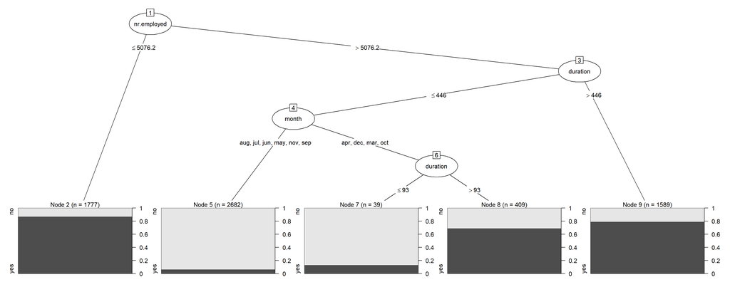

```r
plot(trained_model7)  #Plotting the least complex tree
```

The most complex tree is the trained_model1 with 327 leaf nodes due to a CF value of 0.97 while the least complex tree is trained_model7 with only 5 leaf nodes and a CF value of 0.0005

The model will start by checking the value of nr.employed which if greater than 5076.2 than it will go to node 3 to check the value of duration otherwise it will go to node 2 and give the prediction as “yes”. So, in this case as nr.employed is 6000 > 5076.2, the model will move to node 3 and check the value of duration which if less than 446, it will move to Node 4 and will check the value of month, otherwise it will give us the prediction of “yes”. In our case, as duration = 500 > 446, we will get a prediction of “yes” for the target variable. Therefore, a customer with nr.employed = 600 and duration = 500 will be predicted as “yes” for y i.e. they have subscribed for a CD Deposit.

# 7 Generating Predictions for each model

For each of the seven models, we will predict the target variable ‘y’ for both the training and test sets separately, storing the predictions in variables prefixed with ‘model_X_train_predictions’ and ‘model_X_test_predictions’, where ‘X’ represents the model number. These predictions can be further analyzed for evaluating the performance of each model on both the training and test data.

```r
model_1_train_predictions <- predict(trained_model1,train_set)
model_2_train_predictions <- predict(trained_model2,train_set)
model_3_train_predictions <- predict(trained_model3,train_set)
model_4_train_predictions <- predict(trained_model4,train_set)
model_5_train_predictions <- predict(trained_model5,train_set)
model_6_train_predictions <- predict(trained_model6,train_set)
model_7_train_predictions <- predict(trained_model7,train_set)

model_1_test_predictions <- predict(trained_model1,test_set)
model_2_test_predictions <- predict(trained_model2,test_set)
model_3_test_predictions <- predict(trained_model3,test_set)
model_4_test_predictions <- predict(trained_model4,test_set)
model_5_test_predictions <- predict(trained_model5,test_set)
model_6_test_predictions <- predict(trained_model6,test_set)
model_7_test_predictions <- predict(trained_model7,test_set)
```

# 8 Generating Confusion Matrices for each Model

In this R code, we will generate confusion matrices for all seven decision tree models on both the training and test sets. Each confusion matrix shows the counts of predicted versus observed values of the target variable ‘y’. These matrices provide insight into the performance of each model in classifying the data correctly.

```r
# Creating Confusion Matrix for 7 train sets
Confusion_Matrix_train_1 <- table(predicted = model_1_train_predictions,
                                  observed = train_set$y)
Confusion_Matrix_train_1
```

```
##          observed
## predicted   no  yes
##       no  3005  138
##       yes  243 3110
```

```r
Confusion_Matrix_train_2 <- table(predicted = model_2_train_predictions,
                                  observed = train_set$y)
Confusion_Matrix_train_2
```

```
##          observed
## predicted   no  yes
##       no  2881  165
##       yes  367 3083
```

```r
Confusion_Matrix_train_3 <- table(predicted = model_3_train_predictions,
                                  observed = train_set$y)
Confusion_Matrix_train_3
```

```
##          observed
## predicted   no  yes
##       no  2736  164
##       yes  512 3084
```

```r
Confusion_Matrix_train_4 <- table(predicted = model_4_train_predictions,
                                  observed = train_set$y)
Confusion_Matrix_train_4
```

```
##          observed
## predicted   no  yes
##       no  2734  221
##       yes  514 3027
```

```r
Confusion_Matrix_train_5 <- table(predicted = model_5_train_predictions,
                                  observed = train_set$y)
Confusion_Matrix_train_5
```

```
##          observed
## predicted   no  yes
##       no  2709  212
##       yes  539 3036
```

```r
Confusion_Matrix_train_6 <- table(predicted = model_6_train_predictions,
                                  observed = train_set$y)
Confusion_Matrix_train_6
```

```
##          observed
## predicted   no  yes
##       no  2656  201
##       yes  592 3047
```

```r
Confusion_Matrix_train_7 <- table(predicted = model_7_train_predictions,
                                  observed = train_set$y)
Confusion_Matrix_train_7
```

```
##          observed
## predicted   no  yes
##       no  2548  173
##       yes  700 3075
```

```r
# Creating Confusion Matrix for 7 test sets
Confusion_Matrix_test_1 <- table(predicted = model_1_test_predictions,
                                  observed = test_set$y)
Confusion_Matrix_test_1
```

```
##          observed
## predicted   no  yes
##       no  1180  168
##       yes  212 1224
```

```r
Confusion_Matrix_test_2 <- table(predicted = model_2_test_predictions,
                                  observed = test_set$y)
Confusion_Matrix_test_2
```

```
##          observed
## predicted   no  yes
##       no  1186  124
##       yes  206 1268
```

```r
Confusion_Matrix_test_3 <- table(predicted = model_3_test_predictions,
                                  observed = test_set$y)
Confusion_Matrix_test_3
```

```
##          observed
## predicted   no  yes
##       no  1150   90
##       yes  242 1302
```

```r
Confusion_Matrix_test_4 <- table(predicted = model_4_test_predictions,
                                  observed = test_set$y)
Confusion_Matrix_test_4
```

```
##          observed
## predicted   no  yes
##       no  1169  108
##       yes  223 1284
```

```r
Confusion_Matrix_test_5 <- table(predicted = model_5_test_predictions,
                                  observed = test_set$y)
Confusion_Matrix_test_5
```

```
##          observed
## predicted   no  yes
##       no  1163  101
##       yes  229 1291
```

```r
Confusion_Matrix_test_6 <- table(predicted = model_6_test_predictions,
                                  observed = test_set$y)
Confusion_Matrix_test_6
```

```
##          observed
## predicted   no  yes
##       no  1133   86
##       yes  259 1306
```

```r
Confusion_Matrix_test_7 <- table(predicted = model_7_test_predictions,
                                  observed = test_set$y)
Confusion_Matrix_test_7
```

```
##          observed
## predicted   no  yes
##       no  1104   73
##       yes  288 1319
```

# 9 Generating Evaluation Metrics for each Model

In this R code, we calculate various performance metrics for each of the seven decision tree models trained on the dataset. We compute metrics such as accuracy, precision, recall, and F1-score for both the training and test sets. The results are organized into vectors for each metric and then combined into a dataframe named ‘df_metrics’, providing a comprehensive overview of the performance of each model. Finally, we display the F1 scores for the training and test sets, along with the dataframe containing all metric results.

```r
# creating vectors for all the train accuracy results.
train_acc <- c(
  mmetric(train_set$y, model_1_train_predictions, metric="ACC"),
  mmetric(train_set$y, model_2_train_predictions, metric="ACC"),
  mmetric(train_set$y, model_3_train_predictions, metric="ACC"),
  mmetric(train_set$y, model_4_train_predictions, metric="ACC"),
  mmetric(train_set$y, model_5_train_predictions, metric="ACC"),
  mmetric(train_set$y, model_6_train_predictions, metric="ACC"),
  mmetric(train_set$y, model_7_train_predictions, metric="ACC")
  )

# creating vectors for all the test accuracy results.
test_acc <- c(
  mmetric(test_set$y, model_1_test_predictions, metric = "ACC"),
  mmetric(test_set$y, model_2_test_predictions, metric = "ACC"),
  mmetric(test_set$y, model_3_test_predictions, metric = "ACC"),
  mmetric(test_set$y, model_4_test_predictions, metric = "ACC"),
  mmetric(test_set$y, model_5_test_predictions, metric = "ACC"),
  mmetric(test_set$y, model_6_test_predictions, metric = "ACC"),
  mmetric(test_set$y, model_7_test_predictions, metric = "ACC")
  )

# creating vectors for all the train F1 results.
train_F1 <- c(
  mmetric(train_set$y, model_1_train_predictions, metric="F1"),
  mmetric(train_set$y, model_2_train_predictions, metric="F1"),
  mmetric(train_set$y, model_3_train_predictions, metric="F1"),
  mmetric(train_set$y, model_4_train_predictions, metric="F1"),
  mmetric(train_set$y, model_5_train_predictions, metric="F1"),
  mmetric(train_set$y, model_6_train_predictions, metric="F1"),
  mmetric(train_set$y, model_7_train_predictions, metric="F1")
  )

# creating vectors for all the test F1 results.
test_F1 <- c(
  mmetric(test_set$y, model_1_test_predictions, metric = "F1"),
  mmetric(test_set$y, model_2_test_predictions, metric = "F1"),
  mmetric(test_set$y, model_3_test_predictions, metric = "F1"),
  mmetric(test_set$y, model_4_test_predictions, metric = "F1"),
  mmetric(test_set$y, model_5_test_predictions, metric = "F1"),
  mmetric(test_set$y, model_6_test_predictions, metric = "F1"),
  mmetric(test_set$y, model_7_test_predictions, metric = "F1")
  )

# creating vectors for all the train precision results.
train_prec <- c(
  mmetric(train_set$y, model_1_train_predictions, metric="PRECISION"),
  mmetric(train_set$y, model_2_train_predictions, metric="PRECISION"),
  mmetric(train_set$y, model_3_train_predictions, metric="PRECISION"),
  mmetric(train_set$y, model_4_train_predictions, metric="PRECISION"),
  mmetric(train_set$y, model_5_train_predictions, metric="PRECISION"),
  mmetric(train_set$y, model_6_train_predictions, metric="PRECISION"),
  mmetric(train_set$y, model_7_train_predictions, metric="PRECISION")
  )

# creating vectors for all the test precision results.
test_prec <- c(
  mmetric(test_set$y, model_1_test_predictions, metric = "PRECISION"),
  mmetric(test_set$y, model_2_test_predictions, metric = "PRECISION"),
  mmetric(test_set$y, model_3_test_predictions, metric = "PRECISION"),
  mmetric(test_set$y, model_4_test_predictions, metric = "PRECISION"),
  mmetric(test_set$y, model_5_test_predictions, metric = "PRECISION"),
  mmetric(test_set$y, model_6_test_predictions, metric = "PRECISION"),
  mmetric(test_set$y, model_7_test_predictions, metric = "PRECISION")
  )

# creating vectors for all the train recall results.
train_rec <- c(
  mmetric(train_set$y, model_1_train_predictions, metric="TPR"),
  mmetric(train_set$y, model_2_train_predictions, metric="TPR"),
  mmetric(train_set$y, model_3_train_predictions, metric="TPR"),
  mmetric(train_set$y, model_4_train_predictions, metric="TPR"),
  mmetric(train_set$y, model_5_train_predictions, metric="TPR"),
  mmetric(train_set$y, model_6_train_predictions, metric="TPR"),
  mmetric(train_set$y, model_7_train_predictions, metric="TPR")
  )

# creating vectors for all the test recall results.
test_rec <- c(
  mmetric(test_set$y, model_1_test_predictions, metric = "TPR"),
  mmetric(test_set$y, model_2_test_predictions, metric = "TPR"),
  mmetric(test_set$y, model_3_test_predictions, metric = "TPR"),
  mmetric(test_set$y, model_4_test_predictions, metric = "TPR"),
  mmetric(test_set$y, model_5_test_predictions, metric = "TPR"),
  mmetric(test_set$y, model_6_test_predictions, metric = "TPR"),
  mmetric(test_set$y, model_7_test_predictions, metric = "TPR")
  )

df_metrics <- data.frame(train_acc,test_acc,train_prec,test_prec,train_rec,test_rec,cf_vector,leaf_nodes_vector)

# Calling out data sets for different metrices
train_F1
```

```
##  [1] 94.03849 94.22815 91.54751 92.05733 89.00455 90.12274 88.15089 89.17366
##  [9] 87.82623 88.99311 87.01065 88.48555 85.37443 87.56941
```

```r
test_F1
```

```
##  [1] 86.13139 86.56294 87.78682 88.48569 87.38602 88.69210 87.59835 88.58227
##  [9] 87.57530 88.66758 86.78667 88.33277 85.94784 87.96265
```

```r
df_metrics
```

```
##    train_acc test_acc train_prec test_prec train_rec test_rec cf_vector
## 1   94.13485 86.35057   95.60929  87.53709  92.51847 84.77011    0.9700
## 2   91.81034 88.14655   92.75276  85.23677  95.75123 87.93103    0.3500
## 3   89.59360 88.07471   94.58306  90.53435  88.70074 85.20115    0.1200
## 4   88.68534 88.11063   89.36232  86.02442  94.91995 91.09195    0.0800
## 5   88.43904 88.14655   94.34483  92.74194  84.23645 82.61494    0.0400
## 6   87.79249 87.60776   85.76196  84.32642  94.95074 93.53448    0.0250
## 7   86.56096 87.03305   92.52115  91.54268  84.17488 83.97989    0.0005
## 8   94.13485 86.35057   85.48433  85.20239  93.19581 92.24138    0.9700
## 9   91.81034 88.14655   92.74221  92.00949  83.40517 83.54885    0.3500
## 10  89.59360 88.07471   84.92308  84.93421  93.47291 92.74425    0.1200
## 11  88.68534 88.11063   92.96465  92.94504  81.77340 81.39368    0.0800
## 12  88.43904 88.14655   83.73179  83.45048  93.81158 93.82184    0.0400
## 13  87.79249 87.60776   93.64204  93.79779  78.44828 79.31034    0.0250
## 14  86.56096 87.03305   81.45695  82.07841  94.67365 94.75575    0.0005
##    leaf_nodes_vector
## 1                327
## 2                154
## 3                 47
## 4                 26
## 5                 23
## 6                 16
## 7                  5
## 8                327
## 9                154
## 10                47
## 11                26
## 12                23
## 13                16
## 14                 5
```

# 10 Feature Importance by Model

In this R code chunk, we extract feature importances for each of the seven decision tree models trained on the dataset using the C5.0 algorithm. By calling the C5imp() function on each trained model, we obtain the importance scores of features used by each model in making predictions. These scores provide insights into the relative importance of different features in determining the outcome variable ‘y’ within each decision tree model.

```r
C5imp(trained_model1)
```

```
##                Overall
## duration        100.00
## nr.employed     100.00
## month            69.81
## poutcome         62.19
## contact          40.35
## job              35.27
## emp.var.rate     33.84
## euribor3m        27.96
## day_of_week       8.96
## default           8.94
## cons.conf.idx     8.87
## education         8.81
## loan              7.56
## pdays             6.59
## cons.price.idx    6.00
## campaign          4.77
## marital           3.93
## housing           2.86
## age               2.59
## previous          0.79
```

```r
C5imp(trained_model2)
```

```
##                Overall
## duration        100.00
## nr.employed     100.00
## month            56.76
## poutcome         41.55
## emp.var.rate     32.20
## euribor3m        27.77
## contact          16.52
## cons.conf.idx     8.65
## job               7.53
## day_of_week       6.74
## pdays             6.59
## default           6.30
## loan              6.27
## cons.price.idx    5.93
## age               2.16
## housing           1.94
## education         1.20
## marital           1.15
## campaign          1.02
## previous          0.52
```

```r
C5imp(trained_model3)
```

```
##                Overall
## duration        100.00
## nr.employed     100.00
## month            50.35
## emp.var.rate     43.60
## poutcome         41.29
## contact          16.19
## euribor3m        14.25
## cons.conf.idx     8.65
## default           6.30
## cons.price.idx    5.93
## day_of_week       5.56
## pdays             4.54
## loan              2.69
## age               1.68
## job               1.08
## education         0.58
## marital           0.29
## previous          0.18
## housing           0.00
## campaign          0.00
```

```r
C5imp(trained_model4)
```

```
##                Overall
## duration        100.00
## nr.employed     100.00
## month            48.18
## poutcome         41.29
## contact          13.49
## cons.conf.idx     8.65
## default           6.30
## cons.price.idx    5.93
## day_of_week       5.56
## pdays             4.22
## loan              2.69
## emp.var.rate      2.63
## age               1.62
## euribor3m         1.52
## job               1.08
## marital           0.00
## education         0.00
## housing           0.00
## campaign          0.00
## previous          0.00
```

```r
C5imp(trained_model5)
```

```
##                Overall
## duration        100.00
## nr.employed     100.00
## month            48.18
## poutcome         41.29
## contact          13.49
## default           6.30
## cons.price.idx    5.93
## day_of_week       5.56
## cons.conf.idx     5.56
## emp.var.rate      2.63
## age               1.62
## euribor3m         1.52
## job               1.08
## marital           0.00
## education         0.00
## housing           0.00
## loan              0.00
## campaign          0.00
## pdays             0.00
## previous          0.00
```

```r
C5imp(trained_model6)
```

```
##                Overall
## nr.employed     100.00
## duration         72.64
## month            48.18
## poutcome         41.29
## contact           8.85
## cons.price.idx    6.30
## cons.conf.idx     5.93
## day_of_week       4.66
## emp.var.rate      2.63
## euribor3m         1.69
## age               1.59
## job               0.00
## marital           0.00
## education         0.00
## default           0.00
## housing           0.00
## loan              0.00
## campaign          0.00
## pdays             0.00
## previous          0.00
```

```r
C5imp(trained_model7)
```

```
##                Overall
## nr.employed     100.00
## duration         72.64
## month            48.18
## age               0.00
## job               0.00
## marital           0.00
## education         0.00
## default           0.00
## housing           0.00
## loan              0.00
## contact           0.00
## day_of_week       0.00
## campaign          0.00
## pdays             0.00
## previous          0.00
## poutcome          0.00
## emp.var.rate      0.00
## cons.price.idx    0.00
## cons.conf.idx     0.00
## euribor3m         0.00
```

The top 4 features in the majority of models were:

1. nr.employed,
2. duration,
3. month and
4. poutcome

The 2 least important features were: previous and campaign

# 11 Reflections and Findings

Q: How does changing the CF hyper parameter affect the model complexity?

A: Decreasing the CF hyper parameter decreases the model complexity as seen in the code chunks above. The model created with 0.97 had a tree size of 327 while the model with a CF value of 5e-04 had a tree size of only 5. Hence, it can be deduced that CF is directly proportional to model complexity.

Q: Which model had the best performance in Train set? What was the complexity for this model? How did this model perform in the Train set?

A: Model with a CF value of 0.97 and a tree size of 327 had the best accuracy in train set with a value of 94.13%. Although the test accuracy for this model was significantly decreased when compared to other models with an accuracy of 86.35% from 94.13%.

Q: What is your conclusion about the relationship between model complexity and performance on the Train and Test sets?

Q: Which of the decision tree models is most complex?

A: The most complex decision tree model is the first one “trained_model_1” with a CF value of 0.97 and tree size of 327 nodes.

Q: Which of the decision tree models generalizes to the testing data set the least?

A: Model 1 with a CF value of 0.97 and tree size of 327 has the lowest accuracy in the test set hence “trained_model_1” generalizes to the testing data the least as it is overfitting the train set data.

Q: Take a long look at the test accuracy results: If you were taking these results to a meeting and were explaining how the model makes predictions which model would you choose? Another way of asking this: Which model is the most interpretable?

A: For a meeting where interpretability is a priority, we should prefer models that are simpler, easier to understand but also have a decent value for accuracy in the testing dataset. We need a balance between accuracy and interpretability hence out of the 7 models, we should select ‘trained_model_5’ with a CF value of 0.04 and a total of 23 nodes which is also a bit extensive (typically we would prefer something between 10 to 20 nodes max) but this is the best model in this job as it has a high accuracy of 88.14% in the test data as well.